# Exercícios - Módulo I

J van Melis

22/03/2020

# Módulo I - Introdução ao R

Esse documento tem como objetivo mostrar alguns tutoriais e exercícios que devem ser feitos por você. Você pode realizar os tutoriais que se encontram aqui nesse documento em seu próprio computador utilizando o RStudio. Ao final, encontram-se exercícios que devem ser realizados por você, colocando as linhas de comando em um script (arquivo com extensão .r) e enviar para mim no e-mail jvmelis@gmail.com

As partes que estão em janelas são aquelas que podem ser repetidas em seu console. Exemplo:

```r
print("Hello!")
```

E aqeulas janelas que começam com `##` são aquelas que resultam do comando escrito na última janela mostrada anteriormente. Exemplo (*output* de `print("Hello!")`):

```
## [1] "Hello!"
```

## Tutoriais

Nos exercícios que fizemos até agora, vocês utilizaram alguns operadores. Para relembrá-los, mostrarei cada um:

## I. Conceitos básicos

**Operadores Matemáticos**: São aqueles utilizados para realizar as operações matemáticas mais simples, como soma (`+`), subtração (`-`), multiplicação (`*`) e divisão (`/`). Podemos também incluir a exponenciação (`^`) nesse conjunto e o cálculo da raiz quadrada (`sqrt()` do termo em inglês *square root*). A seguir, temos alguns exemplos de uso:

```r
23 + 45
```

```
## [1] 68
```

```r
105 - 81
```

```
## [1] 24
```

```r
12 * 5
```

```
## [1] 60
```

```r
15 / 3
```

```
## [1] 5
```

```r
3 ^ 3
```

```
## [1] 27
```

```r
sqrt(16)
```

```
## [1] 4
```

**Criar variáveis** Como o R também é uma linguagem orientada a objetos, é importante a criação de objetos. Como todo objeto, podemos montar objetos que tenham características e tamanhos diferentes. Os objetos podem ser variáveis e, para atribuirmos um valor a uma variável, podemos utilizar os símbolos `=` ou `<-`, sendo que aquilo que se encontra do lado esquerdo é a variável e do lado esquerdo o valor (ou conjunto de valores) a ser atribuído à variável.

Importante lembrar que o nome das variáveis **DEVEM**:

```
1. Começar com ao menos uma letra (Não podem começar com números ou símbolos)

2. Evite o uso de símbolos. Por exemplo: `#`, `@`, `!`,`$`, `%`, `&`, `*`, `+`, `-`,  `/`, `(`, `)`, além de acentos e espaços. Símbolo aceitável é `_`.

3. Prefira nomes de variáveis que signifiquem algo e que sejam mais *únicos*. Por exemplo: `DNA_ind235` (DNA do indivíduo 235) ao invés de `gen1` (seria gene ou genoma?) ou `dna` (de quem? Vai ter mais do que uma extração de DNA?).
```

Quanto aos valores, eles podem ser um único valor (0 dimensões), um `vector` (1 dimensão: 1 x n), um `data.frame` (2 dimensões: n linhas e m colunas, sendo que todas as colunas devem ter o mesmo número de linhas), além de `array` (mais do que duas dimensões) e `list` (objetos que podem ter elementos de diferentes tipos: `data.frame`, `vector`, valores, `array`, etc).

#### - Atribuindo um valor a uma variável:

```r
a <- 18.5
b <- 442L
c <- "Qualquer letr@ ou $ímbolo"
d <- TRUE
```

os valores são objetos que podem ter diferentes classes, as classes que construímos acima são de quatro tipos. Podemos ver as classes desses objetos usando a função `class()`:

```r
class(a)
```

```
## [1] "numeric"
```

```r
class(b)
```

```
## [1] "integer"
```

A diferença das classes `numeric` e `integer` é que a segunda classe é para número inteiros. No R, para que um número inteiro seja reconhecido como tal, usa-se a letra maiúscula **L** ao final do número (neste caso `442L`). Lembrando que o R usa numeração “americana” (dígitos separados por `.` e não `,`).

Ambos podem ser utilizados como valores numéricos em operações matemáticas:

```r
a*b
```

```
## [1] 8177
```

Os outros dois objetos não são numéricos, mas cada um tem sua peculiaridade:

```r
class(c)
```

```
## [1] "character"
```

```r
class(d)
```

```
## [1] "logical"
```

Para construir um objeto `character` basta usar aspas (""). Se não forem utilizadas as aspas, o R entenderá que você quer atribuir um objeto/variável a outro objeto/variável (que não existe) ou descrevendo um símbolo não esperado (como um espaço, símbolo ou letra acentuada). Um objeto da classe `character` pode realizar algumas ações, mas logicamente que ações que incluam cálculos não poderão ser realizadas. Veja no seu console os resultados dos comandos a seguir para que você visualize:

Erro com objeto não encontrado:

```r
c <- valor
```

Erro com símbolo inesperado:

```r
c <- valor nao esperado
```

Erro com argumento não-numérico:

```r
2*c
```

Já um objeto lógico pode apresentar dois tipos de valores `TRUE` e `FALSE`. Esse é o objeto mais simples, pois só pode ser um valor ou outro, sendo que numericamente os valores lógicos podem ser: `TRUE` = `1` e `FALSE` = `0`. Portanto, podemos fazer a soma de dois ou mais valores lógicos:

```r
TRUE + FALSE + TRUE
```

```
## [1] 2
```

Sendo essa característica muito útil, onde poderemos ver em exemplos futuros. Os valores de `TRUE` e `FALSE` devem ser escritos com todas as letras em caixa alta e também podem ser sintetizados no R com somente a primeira letra em maiúsculo (`T` e `F`).

```r
T
```

```
## [1] TRUE
```

```r
F
```

```
## [1] FALSE
```

Os valores lógicos podem ser respostas a operadores lógicos, sendo eles: `==` (*igual a*), `!=` (*diferente a*), `>` (*maior que*), `<` (*menor que*), `>=` (*maior ou igual a*), `<=` (*menor ou igual a*). Exemplos:

```r
1 == 2
```

```
## [1] FALSE
```

```r
1 != 2
```

```
## [1] TRUE
```

```r
1 < 2
```

```
## [1] TRUE
```

```r
1 > 2
```

```
## [1] FALSE
```

```r
1 >= 2
```

```
## [1] FALSE
```

```r
1 <= 2
```

```
## [1] TRUE
```

### Exercicio 1.

#### a) Construa a [Fórmula de Bhaskara](https://brasilescola.uol.com.br/matematica/formula-bhaskara.htm) segundo comando no R. Faça duas vezes, pois em uma você utilizará `+` e em outra `-`

#### b) estabeleça os seguintes valores para seu cálculo: `a = 1`,`b = 12`,`c = -13`.

#### - Construindo um `vector`:

Para construir uma sequência de valores que sejam atribuídos a uma única variável/objeto, use a função `c()` (de *combine*), colocando os valores separados por uma vírgula (`,`). Exemplos:

```r
vetor_a <- c(18.5, 22, 44.123456, pi)
vetor_b <- c("abc", "def GHIJ", "!23$ ¨¨(), qualquer", "difícil")
vetor_c <- c(TRUE, FALSE, T, F)
```

Sendo que cada vetor também tem sua classe:

```r
class(vetor_a)
```

```
## [1] "numeric"
```

```r
class(vetor_b)
```

```
## [1] "character"
```

```r
class(vetor_c)
```

```
## [1] "logical"
```

**Observação**: o valor de $\pi$ já está presente no R como o objeto `pi`.

Cada objeto pertencerá a uma classe de objetos que seja a mais inclusiva para todas as variáveis. Portanto, se você fizer um vetor que inclua `character` e `numeric`, todos os valores serão mudados para `character`. Exemplo:

```r
vetor_misto <- c("zero", 1, 2, 3)
class(vetor_misto)
```

```
## [1] "character"
```

A hierarquia no R é:

```
    `logical` < `integer` < `numeric` < `character`.
```

Ou seja, um valor `logical` ao ser gravado com números inteiros (`integer`) será modificado para `integer` (`TRUE` para `1` e `FALSE` para `0`); um número inteiro é modificado para `numeric`; e um número será modificado para `character` se for salvo com outros valores `character` (`1` para `"1"`).

#### - Construindo um `data.frame`

Um data.frame é uma tabela de `n` x `m` (`n` linhas e `m` colunas), sendo que todas as `m` colunas devem ter o mesmo tamanho. Para construir um data.frame, basta usar a função `data.frame()`, juntando dois ou mais vetores. Exemplo:

```r
dados <- data.frame(vetor_a, vetor_c)
dados
```

```
##     vetor_a vetor_c
## 1 18.500000    TRUE
## 2 22.000000   FALSE
## 3 44.123456    TRUE
## 4  3.141593   FALSE
```

possuindo a sua própria classe (`data.frame`):

```r
class(dados)
```

```
## [1] "data.frame"
```

O interessante é que cada coluna mantém a sua classe dentro de um data.frame. Para visualizar isso, utilize a função `str()` (para ver a estrutura do data.frame) ou `summary()` (Para ver o *resumo* do data.frame):

```r
str(dados)
```

```
## 'data.frame':    4 obs. of  2 variables:
##  $ vetor_a: num  18.5 22 44.12 3.14
##  $ vetor_c: logi  TRUE FALSE TRUE FALSE
```

Com `str()` vemos que são duas colunas, uma intitulada `vetor_a` da classe `numerical` (podemos ver com a descrição `num`) e outra chamada `vetor_c` da classe `logical` (podemos ver `logi`).

```r
summary(dados)
```

```
##     vetor_a        vetor_c
##  Min.   : 3.142   Mode :logical
##  1st Qu.:14.660   FALSE:2
##  Median :20.250   TRUE :2
##  Mean   :21.941
##  3rd Qu.:27.531
##  Max.   :44.123
```

Com `summary()` vemos que são duas colunas, uma intitulada `vetor_a` com os seguintes valores:

```
Valor Mínimo (`Min.`) igual a `3.142`
Primeiro quartil (`1st Qu.`) igual a `14.660`
Mediana (`Median`) igual a `20.250`
Média (`Mean`) igual a `21.941`
Terceiro Quartil (`3rd Qu.`) igual a `27.531`
Valor Máximo (`Max.`) igual a `44.123`
```

A segunda coluna intitulada `vetor_c` vemos que é uma coluna com valores lógicos (`Mode: logical`), contabilizando quantos valores de `TRUE` e `FALSE` existem (2, respectivamente).

Na hora de construirmos um data.frame, também podemos colocar nomes diferentes das colunas, desta maneira:

```r
dados <- data.frame(Numeros = vetor_a,
                    Logico = vetor_c)
dados
```

```
##     Numeros Logico
## 1 18.500000   TRUE
## 2 22.000000  FALSE
## 3 44.123456   TRUE
## 4  3.141593  FALSE
```

## II. Usando indexação

Os dois principais objetos que usaremos para a indexação serão vetores e tabelas (`data.frame`). Para a indexação utiliza-se os colchetes (`[]`) e numeração para visualizarmos e/ou extrairmos os valores presentes nesses objetos. No R, o primeiro valor de um vetor é extraído usando o nome do vetor seguido por `[1]`. Caso fosse o segundo valor, usamos `[2]`, e assim por diante. Exemplo:

```r
vetor_letras <- c("primeiro", "segundo", "terceiro", "quarto", "quinto")
vetor_letras
```

```
## [1] "primeiro" "segundo"  "terceiro" "quarto"   "quinto"
```

```r
vetor_letras[1]
```

```
## [1] "primeiro"
```

```r
vetor_letras[2]
```

```
## [1] "segundo"
```

Se quisermos extrair mais do que um valor, podemos utilizar um vetor de números ou uma sequência para extraí-los. Por exemplo, para extrairmos os valores `"primeiro"`, `"terceiro"` e `"quinto"`, utilizamos o vetor de numeros `c(1,3,5)` dentro dos colchetes, desta maneira:

```r
vetor_letras[c(1,3,5)]
```

```
## [1] "primeiro" "terceiro" "quinto"
```

Valores lógicos (`TRUE` e `FALSE`, ou `T` e `F`) também podem ser utilizados:

```r
vetor_letras[c(TRUE, FALSE, TRUE, FALSE, TRUE)]
```

```
## [1] "primeiro" "terceiro" "quinto"
```

Ou se quisermos extrairmos os valores entre `"segundo"` ao `"quarto"`, podemos fazer uma sequência entre 2 e 4, utilizando `2:4` (lê-se: sequência de numeros inteiros entre 2 e 4, espaçados por 1), desta maneira:

```r
vetor_letras[c(2:4)]
```

```
## [1] "segundo"  "terceiro" "quarto"
```

No caso de tabelas, temos duas dimensões: linhas e colunas. Dessa maneira, quando extraimos o valor presente na linha `2` coluna `3`, devemos utilizar `[2,3]`, sendo o primeiro valor referente a linha da tabela e o segundo valor, após a vírgula, referente a coluna. Veja exemplo:

- 1o Criar um data.frame composto por sequências de números:

```r
tabela <- data.frame(Coluna_A = 1:20,
                     Coluna_B = 21:40,
                     Coluna_C = 41:60,
                     Coluna_D = 61:80,
                     Coluna_E = 81:100)
tabela
```

```
##    Coluna_A Coluna_B Coluna_C Coluna_D Coluna_E
## 1         1       21       41       61       81
## 2         2       22       42       62       82
## 3         3       23       43       63       83
## 4         4       24       44       64       84
## 5         5       25       45       65       85
## 6         6       26       46       66       86
## 7         7       27       47       67       87
## 8         8       28       48       68       88
## 9         9       29       49       69       89
## 10       10       30       50       70       90
## 11       11       31       51       71       91
## 12       12       32       52       72       92
## 13       13       33       53       73       93
## 14       14       34       54       74       94
## 15       15       35       55       75       95
## 16       16       36       56       76       96
## 17       17       37       57       77       97
## 18       18       38       58       78       98
## 19       19       39       59       79       99
## 20       20       40       60       80      100
```

Lembrando que usando `:` construimos uma sequência de números no intervalo descrito, e para colocar os nomes das colunas, basta colocar o nome da coluna e `=`, como construído acima.

- 2o Extrair o valor requerido (2a linha, 3a coluna):

```r
tabela[2,3]
```

```
## [1] 42
```

Intervalos também podem ser utilizados. Por exemplo, extraindo as 6 primeiras linhas (`1` a `6`) e entre as colunas `3` e `5`.

```r
tabela[1:6, 3:5]
```

```
##   Coluna_C Coluna_D Coluna_E
## 1       41       61       81
## 2       42       62       82
## 3       43       63       83
## 4       44       64       84
## 5       45       65       85
## 6       46       66       86
```

Se deixarmos o argumento de linha ou de coluna em branco, todas as linhas ou colunas vão ser disponibilizadas. Por exemplo:

**a)** Deixando o argumento de **linhas** em branco, selecionando a **coluna** 3:

```r
tabela[,3]
```

```
##  [1] 41 42 43 44 45 46 47 48 49 50 51 52 53 54 55 56 57 58 59 60
```

**b)** Deixando o argumento de **colunas** em branco, selecionando a **linha** 3:

```r
tabela[3,]
```

```
##   Coluna_A Coluna_B Coluna_C Coluna_D Coluna_E
## 3        3       23       43       63       83
```

Em um data.frame também podemos isolar colunas usando `$`, desta maneira:

```r
tabela$Coluna_A
```

```
##  [1]  1  2  3  4  5  6  7  8  9 10 11 12 13 14 15 16 17 18 19 20
```

## III. Usando indexação e operadores lógicos

Podemos mesclar o conhecimento sobre indexação e o uso de operadores lógicos para selecionar somente uma parte de uma tabela. Para esse exemplo, utilizaremos os dados de `mtcars`, que podem ser obtidos diretamente no R usando a **função** `data()`. Dessa maneira:

```r
data("mtcars")
```

Podemos visualizar as primeiras 6 linhas dessa tabela usando a função `head()`:

```r
head(mtcars)
```

```
##                    mpg cyl disp  hp drat    wt  qsec vs am gear carb
## Mazda RX4         21.0   6  160 110 3.90 2.620 16.46  0  1    4    4
## Mazda RX4 Wag     21.0   6  160 110 3.90 2.875 17.02  0  1    4    4
## Datsun 710        22.8   4  108  93 3.85 2.320 18.61  1  1    4    1
## Hornet 4 Drive    21.4   6  258 110 3.08 3.215 19.44  1  0    3    1
## Hornet Sportabout 18.7   8  360 175 3.15 3.440 17.02  0  0    3    2
## Valiant           18.1   6  225 105 2.76 3.460 20.22  1  0    3    1
```

No caso desta tabela, cada linha tem um nome e referem-se aos nomes dos modelos de carros avaliados. Para ver mais informações sobre esses dados, você pode usar o comando `?mtcars` em seu console, ou ir até esse [link](https://stat.ethz.ch/R-manual/R-devel/library/datasets/html/mtcars.html) (em inglês).

Se realizarmos um teste com operador lógico, observaremos como resposta uma série de `TRUE` ou `FALSE`. Veja o exemplo a seguir, para sabermos se existem carros com 6 cilindros (`cyl == 6`):

```r
mtcars$cyl == 6
```

```
##  [1]  TRUE  TRUE FALSE  TRUE FALSE  TRUE FALSE FALSE FALSE  TRUE  TRUE FALSE
## [13] FALSE FALSE FALSE FALSE FALSE FALSE FALSE FALSE FALSE FALSE FALSE FALSE
## [25] FALSE FALSE FALSE FALSE FALSE  TRUE FALSE FALSE
```

Desta maneira, podemos extrair essa sequência (vetor) de valores lógicos (`TRUE`/`FALSE`) para um novo objeto chamado `carros_6cyl`:

```r
carros_6cyl <- mtcars$cyl == 6
```

E com esse vetor, utilizar para selecionar as linhas da tabela que seguem (com resposta igual a `TRUE`) o operador lógico executado (`mtcars$cyl == 6`):

```r
mtcars[carros_6cyl,]
```

```
##                 mpg cyl  disp  hp drat    wt  qsec vs am gear carb
## Mazda RX4      21.0   6 160.0 110 3.90 2.620 16.46  0  1    4    4
## Mazda RX4 Wag  21.0   6 160.0 110 3.90 2.875 17.02  0  1    4    4
## Hornet 4 Drive 21.4   6 258.0 110 3.08 3.215 19.44  1  0    3    1
## Valiant        18.1   6 225.0 105 2.76 3.460 20.22  1  0    3    1
## Merc 280       19.2   6 167.6 123 3.92 3.440 18.30  1  0    4    4
## Merc 280C      17.8   6 167.6 123 3.92 3.440 18.90  1  0    4    4
## Ferrari Dino   19.7   6 145.0 175 3.62 2.770 15.50  0  1    5    6
```

Ou simplesmente podemos sintetizar esses comandos em um só (sem a construção do objeto `carros_6cyl`):

```r
mtcars[mtcars$cyl == 6, ]
```

```
##                 mpg cyl  disp  hp drat    wt  qsec vs am gear carb
## Mazda RX4      21.0   6 160.0 110 3.90 2.620 16.46  0  1    4    4
## Mazda RX4 Wag  21.0   6 160.0 110 3.90 2.875 17.02  0  1    4    4
## Hornet 4 Drive 21.4   6 258.0 110 3.08 3.215 19.44  1  0    3    1
## Valiant        18.1   6 225.0 105 2.76 3.460 20.22  1  0    3    1
## Merc 280       19.2   6 167.6 123 3.92 3.440 18.30  1  0    4    4
## Merc 280C      17.8   6 167.6 123 3.92 3.440 18.90  1  0    4    4
## Ferrari Dino   19.7   6 145.0 175 3.62 2.770 15.50  0  1    5    6
```

```
    Não se esqueça que em data.frame existe a vírgula (`,`) para separar linha e coluna!
```

### Exercício 2.

#### a) Utilizando `[]`, veja entre as colunas `2` e `5` do data.frame `mtcars`

#### b) Utilizando `:`, veja entre as linhas `11` e `22` do data.frame `mtcars`

#### c) Utilizando `$`, extraia os três primeiros valores da coluna `qsec` do data.frame `mtcars`

### Exercicio 3.

#### e) Organize o data.frame `mtcars` a partir de `mpg`, mostrando os valores com maior `mpg` para aqueles com menor `mpg`. Para isso, utilize a função `order()`. Use `?` para ajudar a responder.

## IV. Estruturas condicionais

Condicionais são expressões que executam cálculos ou ações diferentes, dependendo de uma condição booleana pré-definida ser `TRUE` ou `FALSE`. Instruções condicionais incluem `if()` e a combinação `if()` / `else()`. A estrutura das expressões lógicas é basicamente **SE** um fato ocorrer **ENTÃO** fazer determinada ação. No R, utilizamos o `if` para isso.

Abaixo segue alguns exemplos do uso dessas estruturas: Utilizaremos o consumo (`mpg`) do primeiro carro dos dados `mtcars` (chamaremos de `primeiro_carro`) e pediremos para que imprima (função `print()`) caso o carro seja considerado `"o carro é econômico!"`. Ou seja, se `mpg > 20` resultar em `TRUE`, ele imprimirá no console do R o resultado `"o carro é econômico"`. A estrutura básica dessa expressão é:

**SE** (`if`) `primeiro_carro` (`mpg` do primeiro carro) for maior que `20` (`mpg > 20`) **ENTÃO** (utilizamos `{}`) imprima (`print()`) `"o carro é econômico!"`. Veja como fica o código:

```r
primeiro_carro <- mtcars$mpg[1]

if(primeiro_carro > 20){
    print("o carro é econômico!")
}
```

```
## [1] "o carro é econômico!"
```

Sim! `"o carro é econômico!"`, pois ele consome 1 galão para percorrer mais do que 20 milhas (`mtcars$mpg > 20`).

Porém, nesse tipo de expressão lógica, ainda falta o **SENÃO**, ou seja, caso a expressão lógica não resulte em `TRUE`, mas resulte em `FALSE`. Para isso, utilizamos a expressão `else`. Veja como fica o código e a aplicação no `quinto_carro`:

```r
quinto_carro <- mtcars$mpg[5]

if(quinto_carro > 20){
    print("o carro é econômico!")
    } else{
        print("o carro é beberrão...")
}
```

```
## [1] "o carro é beberrão..."
```

Ou seja, “o carro é beberrão…”, como podemos ver pelo valor que ele apresenta:

```r
quinto_carro
```

```
## [1] 18.7
```

## V. Estrutura de repetição ou de loop

Outro aspecto importante para quem trabalha com programação é o uso de loopings (repetições). Estruturas em loop ou de repetição nada mais são do que automatizações de um processo que possui várias etapas. Essas estruturas organizam sequências de ações e agrupam as partes que precisam ser repetidas de um algoritmo. Para isso, utilizaremos a ferramenta `for()`. Essa ferramenta é útil para que seja utilizado um determinado algoritmo **POR** `n` vezes. Veja o exemplo abaixo:

Utilizaremos o algoritmo de imprimir (`print()`) os números que estão presentes no intervalo entre `1` a `20`. Por isso, queremos que o algoritmo `print(i)` seja realizado `20` vezes, sendo que `i` é um número que está presente em (`in`) um intervalo entre `1` a `20` (`1:20`).

```r
for(i in 1:20){
    print(i)
}
```

```
## [1] 1
## [1] 2
## [1] 3
## [1] 4
## [1] 5
## [1] 6
## [1] 7
## [1] 8
## [1] 9
## [1] 10
## [1] 11
## [1] 12
## [1] 13
## [1] 14
## [1] 15
## [1] 16
## [1] 17
## [1] 18
## [1] 19
## [1] 20
```

No tópico anterior, com o uso de `if` e `else`, aplicamos um algoritmo (**SE** o carro consume pouco **ENTÃO** imprimir `"o carro é econômico"` **SENÃO** imprimir `"o carro é beberrão"`) para um carro. Mas se quisermos automatizar esse algoritmo e rodar esse algoritmo **PARA** todo o conjunto de carros, utilizaremos uma iteração (loop) utilizando a função `for`. Veja a resolução:

```r
consumo_todos_carros <- mtcars$mpg
total_de_carros <- length(consumo_todos_carros)

for(i in 1:total_de_carros){
    if(consumo_todos_carros[i] > 20){
    print("o carro é econômico!")
    } else{
        print("o carro é beberrão...")
        }
}
```

```
## [1] "o carro é econômico!"
## [1] "o carro é econômico!"
## [1] "o carro é econômico!"
## [1] "o carro é econômico!"
## [1] "o carro é beberrão..."
## [1] "o carro é beberrão..."
## [1] "o carro é beberrão..."
## [1] "o carro é econômico!"
## [1] "o carro é econômico!"
## [1] "o carro é beberrão..."
## [1] "o carro é beberrão..."
## [1] "o carro é beberrão..."
## [1] "o carro é beberrão..."
## [1] "o carro é beberrão..."
## [1] "o carro é beberrão..."
```

[output cut: 17 more lines]

Entenda o que foi realizado: 1. Primeiramente extraímos os valores de `mpg` do data.frame `mtcars`, atribuindo a um objeto chamado `consumo_todos_carros`; 2. Depois extraímos o total de carros presentes nessa tabela. No caso, é o comprimento (`length()`) do vetor `consumo_todos_carros`. 3. Construímos a iteração, onde todos os valores presentes em `consumo_todos_carros` serão analisados um a um (`i` que vai de 1 ao número `total_de_carros`), realizando o algoritmo com expressões lógicas.

De um modo geral, há dois tipos de estruturas de repetição (ou loops): `for` e `while`. Na estrutura do `for` os loops são executados por um número prescrito de vezes, conforme o controle de um contador ou um índice, que é incrementado a cada ciclo de iteração. Já na estrutura do `while`, uma condição lógica é inicialmente verificada no início do loop, o qual só é exacutado enquando a condição lógica verificada é verdadeira.

Veja as diferenças:

```r
cidades <- c("São Paulo", "Rio de Janeiro", "Fortaleza")

for(cidade in cidades){
  print(paste("A cidade", cidade, "está entre as mais afetadas pelo corona vírus no Brasil"))
}
```

```
## [1] "A cidade São Paulo está entre as mais afetadas pelo corona vírus no Brasil"
## [1] "A cidade Rio de Janeiro está entre as mais afetadas pelo corona vírus no Brasil"
## [1] "A cidade Fortaleza está entre as mais afetadas pelo corona vírus no Brasil"
```

```r
#podemos juntar as estruturas de repetição e as condicionais

for(cidade in cidades){
  if(cidade == "São Paulo"){
    print(paste(cidade, "é a cidade mais afetada pelo corona vírus no Brasil"))
  }else{
    print(paste("A cidade", cidade, "está entre as mais afetadas pelo corona vírus no Brasil"))
  }
}
```

```
## [1] "São Paulo é a cidade mais afetada pelo corona vírus no Brasil"
## [1] "A cidade Rio de Janeiro está entre as mais afetadas pelo corona vírus no Brasil"
## [1] "A cidade Fortaleza está entre as mais afetadas pelo corona vírus no Brasil"
```

```r
# O comando while executa um comando enquanto a condição que ele avalia for verdadeira, caso ela seja falsa ele deixa de executar o comando

idade <- 2

while(idade <= 18){
  print(paste("Você tem", idade, "anos.", "Você é menor de idade!"))
  idade <- idade + 1 # aumentamos em uma unidade o valor de idade
}
```

```
## [1] "Você tem 2 anos. Você é menor de idade!"
## [1] "Você tem 3 anos. Você é menor de idade!"
## [1] "Você tem 4 anos. Você é menor de idade!"
## [1] "Você tem 5 anos. Você é menor de idade!"
## [1] "Você tem 6 anos. Você é menor de idade!"
## [1] "Você tem 7 anos. Você é menor de idade!"
## [1] "Você tem 8 anos. Você é menor de idade!"
## [1] "Você tem 9 anos. Você é menor de idade!"
## [1] "Você tem 10 anos. Você é menor de idade!"
## [1] "Você tem 11 anos. Você é menor de idade!"
## [1] "Você tem 12 anos. Você é menor de idade!"
## [1] "Você tem 13 anos. Você é menor de idade!"
## [1] "Você tem 14 anos. Você é menor de idade!"
## [1] "Você tem 15 anos. Você é menor de idade!"
## [1] "Você tem 16 anos. Você é menor de idade!"
## [1] "Você tem 17 anos. Você é menor de idade!"
## [1] "Você tem 18 anos. Você é menor de idade!"
```

outra aplicação:

```r
idade <- 1
while(idade <= 18){
  if(idade %% 2 == 0){
  print("Você é menor de idade e sua idade é um número par")
} else{
  print("Você é menor de idade e sua idade é um número ímpar")
}
idade <- idade + 1 #incrementamos em uma unidade o valor de idade
}
```

```
## [1] "Você é menor de idade e sua idade é um número ímpar"
## [1] "Você é menor de idade e sua idade é um número par"
## [1] "Você é menor de idade e sua idade é um número ímpar"
## [1] "Você é menor de idade e sua idade é um número par"
## [1] "Você é menor de idade e sua idade é um número ímpar"
## [1] "Você é menor de idade e sua idade é um número par"
## [1] "Você é menor de idade e sua idade é um número ímpar"
## [1] "Você é menor de idade e sua idade é um número par"
## [1] "Você é menor de idade e sua idade é um número ímpar"
## [1] "Você é menor de idade e sua idade é um número par"
## [1] "Você é menor de idade e sua idade é um número ímpar"
## [1] "Você é menor de idade e sua idade é um número par"
## [1] "Você é menor de idade e sua idade é um número ímpar"
## [1] "Você é menor de idade e sua idade é um número par"
## [1] "Você é menor de idade e sua idade é um número ímpar"
## [1] "Você é menor de idade e sua idade é um número par"
## [1] "Você é menor de idade e sua idade é um número ímpar"
## [1] "Você é menor de idade e sua idade é um número par"
```

### Exercício 4.

#### a) Construa uma iteração, avaliando com um algoritmo com expressão lógica, a coluna `am`, onde o teste a ser realizado é: se `am == 0`, logo imprimir `"câmbio automático"`, caso contrário `"câmbio manual"`.

#### b) Salve o resultado da iteração realizada em objeto chamado `resultado`.

#### c) Utilize a função `summary()` e responda quantos carros tem câmbio automático e quantos tem câmbio manual no data.frame `mtcars`.

## VI. Criando uma função

Por último, lembre-se **sempre** que trabalhos repetitivos devem ser realizados pelo computador! Por isso, criar funções é muito importante para quem trabalha com bioinformática. Criar uma função é estabelecer um algoritmo criado por você! Então, veja como podemos construir um algoritmo e aplicá-lo com uma função.

Vamos supor que você queira calcular a área de um retangulo, que é simplesmente a multiplicação dos valores da base e da altura desse retângulo. Veja a figura abaixo sobre paralelogramas (Fonte: [Wikipedia](https://pt.wikipedia.org/wiki/Ficheiro:%C3%81rea_dos_Paralelogramos.png) )

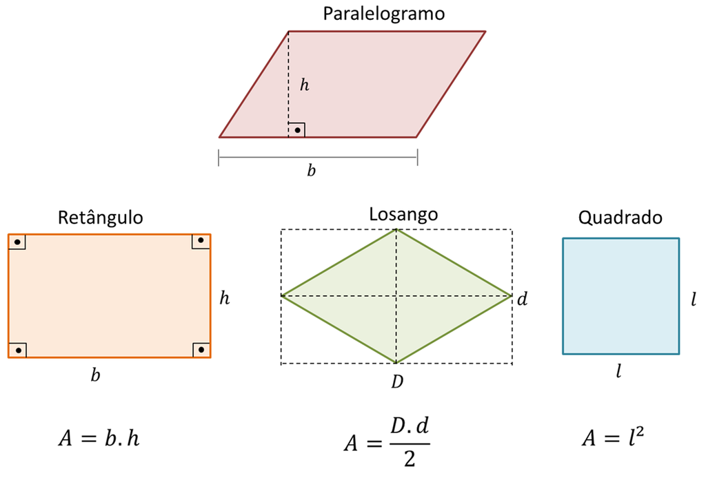

Figura 1 - Área dos Paralelogramas

Como pode ver, para o cálculo da área ($A$) devemos realizar a multiplicação do comprimento da base ($b$) e da altura ($h$):

$$A = b.h$$

Se fossemos calcular a área (`A`) de um retângulo com base (`b`) igual a 2 e altura (`h`) igual a 3, poderíamos realizar o seguinte algoritmo:

```r
b <- 2
h <- 3
A <- b*h
A
```

```
## [1] 6
```

Ou poderíamos construir uma função em que nos retornaria o valor da área de um retângulo, logo após inserirmos dois valores na função. Veja como construir tal função: Para isso, utilizaremos a função `function()` e devemos descrever quais **argumentos** deverão ser utilizadas pela função.

A sintaxe básica para a criação de uma função no R é a seguinte:

```r
nome_da_funcao <- function(arg1, arg2,...){
  comandos que a funcao deve executar
}
```

No nosso caso, os argumentos são base (`b`) e altura (`h`). Para descrever como é o algoritmo, abra e feche as linhas de comando com chaves (`{}`). Veja a construção da função `calcular_area` utilizando o algoritmo para o cálculo da área de um retângulo:

```r
calcular_area <- function(b, h){
    Area = b*h
}
```

Podemos ver agora a sua aplicação, com um retângulo que tem base (`b`) igual a `4` e altura (`h`) igual `3`:

```r
area <- calcular_area(b = 4, h = 3)
area
```

```
## [1] 12
```

Na maneira que fizemos a função, ela não nos retorna um valor de forma automática. Veja abaixo:

```r
calcular_area(b = 4, h = 3)
```

Por isso, é melhor reescrever a função utilizando um comando (função) para nos retornar o valor de `A`, utilizando `return()`:

```r
calcular_area <- function(b, h){
    Area = b*h
    return(Area)
}
```

Desta maneira, a função `calcular_area` vai nos retornar automaticamente o valor da nossa área (`A`):

```r
calcular_area(b = 4, h = 3)
```

```
## [1] 12
```

Importante notar que os objetos criados dentro da função não ficam no ambiente do R (não existe o objeto `Area`, por exemplo).

Você pode ver quais são os argumentos presentes em uma função com a função `args()`

```r
args(calcular_area)
```

```
## function (b, h)
## NULL
```

### Exercício 5.

#### a) Construa uma função que calcule a média aritimética de um vetor de números.

#### b) Testar com o seguinte vetor de números `vetor_com_NA <- c(2, 2, 2, NA)`

#### c) Execute o mesmo teste, mas dessa vez, ao invés de usar a sua própria função, utilize: `mean(vetor_com_NA, na.rm = TRUE)`. Compare os resultados. Os valores são iguais ou não? Por quê?

No R há várias funções já definidas. Alguns exemplos incluem: `mean(x)`, `max(x)`, `sum(x)`, que respectivamente calculam a média, o valor máximo e a soma de números contidos em um dado objeto `x`.

No exercício anterior, apresentei pela primeira vez o valor chamado `NA`. Esse valor é um símbolo para valores *não disponíveis* (*Not Available*). Além de `NA`, também existe o `NaN`, que se refere a *Not a Number*, que são valores impossiveis, como a raiz quadrada de um número negativo:

```r
sqrt(-1)
```

```
## [1] NaN
```

Outros valores que podem aparecer também são `Inf` ou `-Inf`, referentes a valores infinitos, e `NULL`, que refere-se a valores vazios (*nulo*). Exemplos:

```r
vetor_vazio <- c()
vetor_vazio
```

[output not shown]

```r
pi/0
```

```
## [1] Inf
```

```r
-pi/0
```

```
## [1] -Inf
```

## Dica

A página do grupo Rladies São Paulo no github reúne todo o material apresentado pelo grupo nos meetups que elas oferecem. Lá há mais explicações e mais exemplos que os alunos podem tentar reproduzir para aprender melhor tudo o que foi passado. Indicamos especialmente os seguintes materiais:

- Primeira oficina de R básico do grupo

https://maryms.github.io/2019-02-R-Basics-R-LadiesSP/#1

- Oficina de R intermediário

https://beatrizmilz.github.io/2019-02-R-Interm-R-LadiesSP/#1

- Última versão da oficina de R básico apresentada em fevereiro desse ano

https://beatrizmilz.github.io/2020-R-Ladies-SP-Basico/#1